# Project_1

Sanjeev’s SupeRstars: Aaron Zelmanov, Muhammad Hafizudeen Mohamad Saman, Nakul Chadha, Kendall Cohen, Michael Geraci, Michael Zhang

2/21/2021

### Introduction

**Context:** We are working with the hotel_booking.csv dataset to better understand hotel bookings and cancellations. This dataset includes information about: dates, demographics, customer types, reservation details, cancellations, etc.

**Audience:** Hotel managers who are worried about hotel cancellations

**Key Question:** What are the root causes of cancellations and how can we mitigate this issue?

### Are Cancellations a Problem?

In order to understand if cancellations are a real problem, we must explore our data! We will analyze the number of cancellations and proportion of cancellations over time and then figure out how much this is affecting our revenue

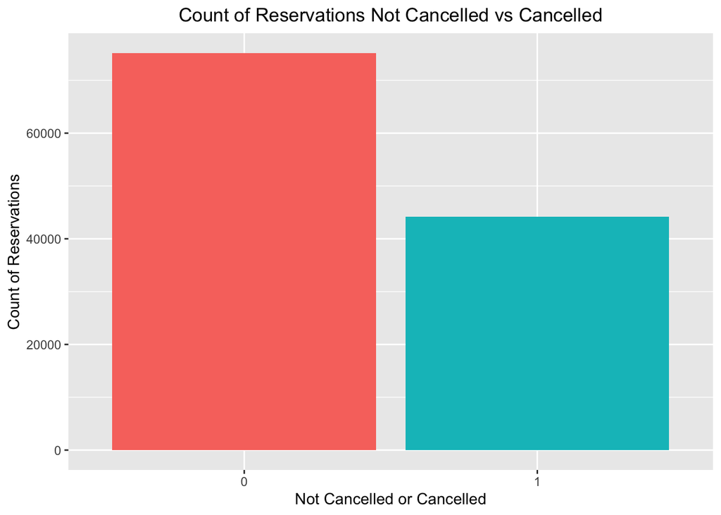

```r
#graph of number of cancellations using ggplot: x,y,titles,alignment,legends, etc.
cancellationNumberPlot <- ggplot(data=hotel, aes(x=is_canceled, fill=is_canceled)) + geom_bar() + xlab("Not Cancelled or Cancelled") + ylab("Count of Reservations") + ggtitle("Count of Reservations Not Cancelled vs Cancelled") + theme(plot.title = element_text(hjust = 0.5), plot.caption = element_text(hjust = 0.5))
cancellationNumberPlot + guides(fill = FALSE)
```

*The graph above displays the number of cancellations across all the data. The total number is 44,224 and the total number of reservations is 119,390. Thus, we can see that there have been a significant number of cancellations over the 2+ year period of this data. Next, we will look at the proportion of cancellations compared to bookings.*

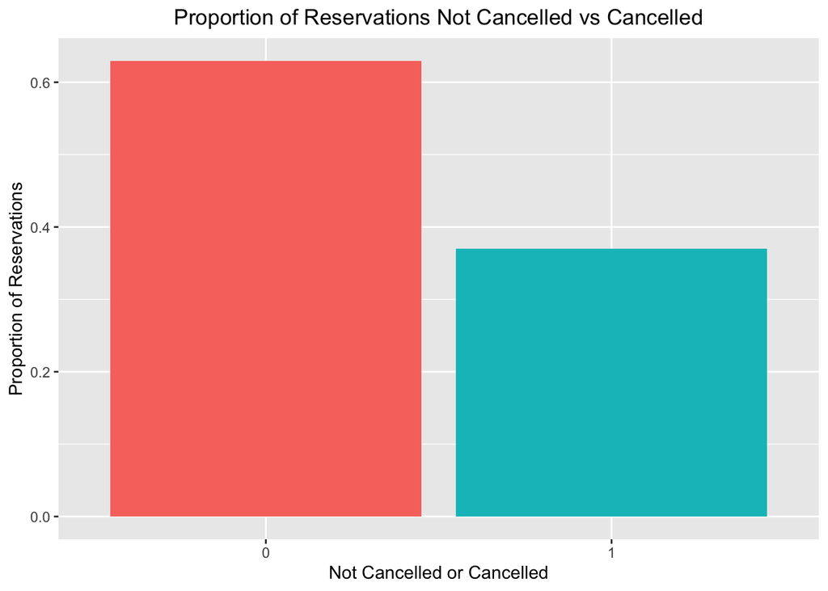

```r
#graph of proportion  of cancellations using ggplot: x,y,titles,alignment,legends, etc.
cancellationPropPlot <- ggplot(data=hotel, aes(x=is_canceled, y=(..count..)/sum(..count..), fill=is_canceled)) + geom_bar() + xlab("Not Cancelled or Cancelled") + ylab("Proportion of Reservations") + ggtitle("Proportion of Reservations Not Cancelled vs Cancelled") + theme(plot.title = element_text(hjust = 0.5), plot.caption = element_text(hjust = 0.5)) + guides(fill = FALSE)
cancellationPropPlot
```

*The graph above displays the proportion of cancellations across all the data. More than a third of bookings (37%) were cancelled, which is a significant amount, further illustrating that cancellations are indeed a problem.*

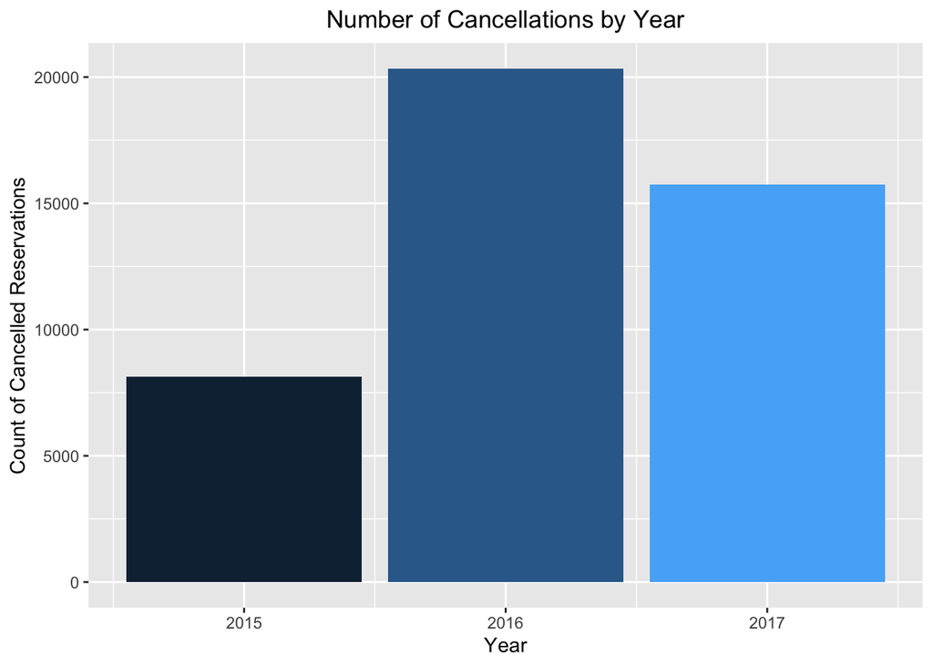

```r
#calculating cancellations in each year through logical indexing into a table and finding the number of rows
cancellations2015Table <- hotel[hotel$is_canceled==1 & hotel$arrival_date_year==2015,]
cancellations2015 <- nrow(cancellations2015Table)
cancellations2016Table <- hotel[hotel$is_canceled==1 & hotel$arrival_date_year==2016,]
cancellations2016 <- nrow(cancellations2016Table)
cancellations2017Table <- hotel[hotel$is_canceled==1 & hotel$arrival_date_year==2017,]
cancellations2017 <- nrow(cancellations2017Table)

#calculating bookings in each year through logical indexing into a table and finding the number of rows
bookings2015Table <- hotel[hotel$arrival_date_year==2015,]
bookings2015 <- nrow(bookings2015Table)
bookings2016Table <- hotel[hotel$arrival_date_year==2016,]
bookings2016 <- nrow(bookings2016Table)
bookings2017Table <- hotel[hotel$arrival_date_year==2017,]
bookings2017 <- nrow(bookings2017Table)

#creatiing table with count and proportion of cancellations per year
table1 <- data_frame(year = c(2015,2016,2017), count = c(cancellations2015,cancellations2016,cancellations2017), prop = c(cancellations2015/bookings2015,cancellations2016/bookings2016,cancellations2017/bookings2017))

#bar graph of number of cancellations per year
cancellationNumberByYear<- ggplot(data=table1, aes(x=year,y=count,fill=year)) + geom_bar(stat='identity') + ggtitle("Number of Cancellations by Year") + labs(x="Year", y="Count of Cancelled Reservations") + theme(plot.title = element_text(hjust = 0.5), plot.caption = element_text(hjust = 0.5)) + guides(fill = FALSE)
cancellationNumberByYear
```

*Looking at the yearly data, the number of cancellations increased from 2015 to 2016 but has decreased since then. In order to better understand what is going on, we will take a look at the monthly number of cancellations next.*

[figure not shown]

```r
#line graph of number of monthly cancellations over time
hotel$is_canceled_2 <- as.numeric(hotel$is_canceled) #can't use factor variable
hotel$month_year <- as.yearmon(paste(hotel$arrival_date_month, hotel$arrival_date_year))
hotel %>% group_by(month_year) %>%
   summarize(sum_canceled=sum(is_canceled_2)) %>% ggplot() + geom_point(aes(x=month_year, y=sum_canceled)) + geom_line(aes(x=month_year, y=sum_canceled)) + ggtitle("Number of Cancellations by Month over Time") + labs(x="Month and Year", y="Count of Cancelled Reservations") + theme(plot.title = element_text(hjust = 0.5), plot.caption = element_text(hjust = 0.5))
```

*The number of monthly cancellations are variable (seasonality + idiosyncratic effects) but show a somewhat increasing trend over time, perhaps with a slight decrease in recent months. This reinforces the idea that cancellations continue to remain a relevant concern for hotel managers.*

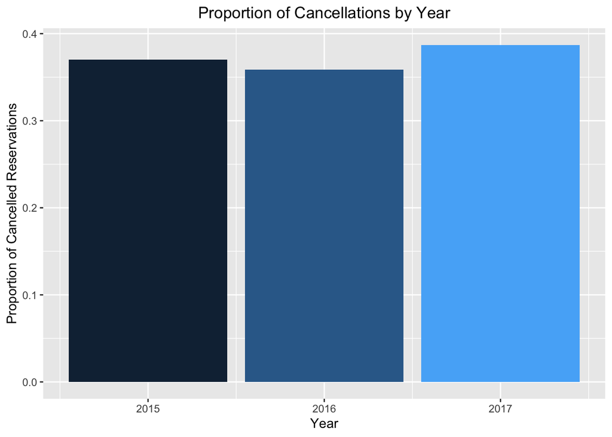

```r
#bar graph of proportion of cancellations per year
cancellationPropByYear <- ggplot(data=table1, aes(x=year,y=prop, fill=year)) + geom_bar(stat='identity') + ggtitle("Proportion of Cancellations by Year") + labs(x="Year", y="Proportion of Cancelled Reservations") + theme(plot.title = element_text(hjust = 0.5), plot.caption = element_text(hjust = 0.5)) + guides(fill = FALSE)
cancellationPropByYear
```

*The proportion of cancellations decreased from 2015 to 2016 but has slightly increased since then. This is a concerning trend but to better understand what is going on, we will take a look at the monthly proportion of cancellations next.*

[figure not shown]

```r
#line graph of proportion of monthly cancellations over time
hotel$month_year <- as.yearmon(paste(hotel$arrival_date_month, hotel$arrival_date_year))
hotel %>% group_by(month_year) %>%
    summarize (n=n()) %>% mutate(prop_canceled=sum(n)/n) %>% ggplot() + geom_point(aes(x=month_year, y=prop_canceled)) + geom_line(aes(x=month_year, y=prop_canceled)) + ggtitle("Proportion of Cancellations by Month over Time") + labs(x="Month and Year", y="Proportion of Cancelled Reservations") + theme(plot.title = element_text(hjust = 0.5), plot.caption = element_text(hjust = 0.5))
```

*The proportion of cancellations are also variable but show a somewhat decreasing trend with a slight increase in recent months. Although we will need to keep monitoring this, this could continue to be an issue for hotel managers.*  
*Conclusion: Although there is a high amount of variability in both counts and proportions of cancellations, we can draw a few insights. The number of cancellations and the proportion of cancellations are extremely high. In recent months, we are observing a slight decrease in cancellations and slight increase in proportion of bookings cancelled. This means that demand might be decreasing. Thus, we must understand what’s causing these cancellations and perhaps if those same factors are affecting demand too. But first, let’s understand if these high number of cancellations also result in a hight amount of lost revenue.*  
**Are we losing money because of the cancellations?**

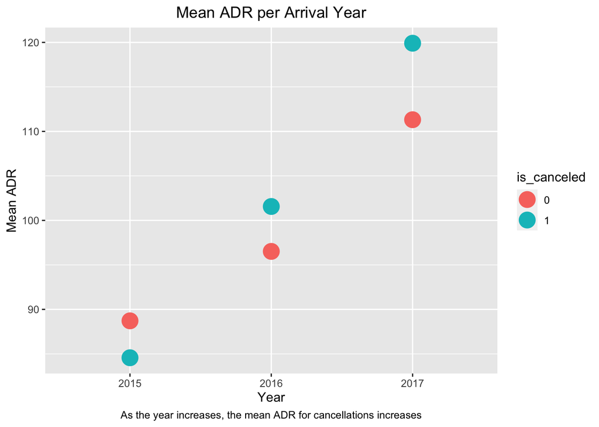

```r
#plot of mean ADR per arrival year
mean_adr_per_year <- aggregate(adr ~ arrival_date_year + is_canceled, data = hotel, mean)
graph <- ggplot(data = as.data.frame(mean_adr_per_year), aes(x=arrival_date_year, y = adr, color = is_canceled)) + geom_point(size = 6) + ggtitle("Mean ADR per Arrival Year") + labs(x = "Year", y="Mean ADR", caption=("As the year increases, the mean ADR for cancellations increases")) + theme(plot.title = element_text(hjust = 0.5), plot.caption = element_text(hjust = 0.5))
graph
```

```r
mean_adr_per_year #also in tabular format
```

```
##   arrival_date_year is_canceled       adr
## 1              2015           0  88.71419
## 2              2016           0  96.51591
## 3              2017           0 111.31204
## 4              2015           1  84.56549
## 5              2016           1 101.56272
## 6              2017           1 119.90660
```

*The table and the graph above demonstrate a couple of interesting observations. Initially, those that do not cancel have a higher mean ADR. However, this switches in 2016 and 2017, where the reservations that are cancelled have a higher mean ADR. Also, between 2016 and 2017, the difference expands between the two. Therefore, as the arrival year progresses, the more money on average do both hotels lose.*

**Mean ADR vs Cancellation Status**

```r
#data frame for mean ADR vs cancellation status
table_mean_adr_canceled <- tapply(hotel$adr, hotel$is_canceled, mean, na.rm = TRUE)
df <- as.data.frame(table_mean_adr_canceled)
colnames(df) <- c("Mean ADR")
df$`Mean ADR` <- as.numeric(as.character(df$`Mean ADR`))
df$`Mean ADR` <- round(df$`Mean ADR`, 2)
df
```

```
##   Mean ADR
## 0    99.99
## 1   104.96
```

*The table above shows the mean ADR for if the reservation was not cancelled and cancelled. As we can discern, the mean ADR is 5 dollars higher for cancelled reservations. Although this may not constitute a large difference, if extrapolated to the entire data set of almost 120,000 reservations, a large amount of money is lost. Namely, if we multiply the mean ADR by the total number of cancellations:*  
**Estimate of Lost Revenue due to Cancellations**

```r
priceR::format_dollars(104.96 * 44224) #dollar calculation
```

```
## [1] "$4,641,751"
```

*As demonstrated, more than $4.5 million dollars is lost.*  
**Deposit Type vs Number of Cancellations**

```r
#cancellations based on deposit type
table_deposit_type <- table(hotel$deposit_type, hotel$is_canceled)
addmargins(table_deposit_type)
```

```
##
##                   0      1    Sum
##   No Deposit  74947  29694 104641
##   Non Refund     93  14494  14587
##   Refundable    126     36    162
##   Sum         75166  44224 119390
```

**Deposit Type vs Proportion of Cancellations**

```r
#proportion of cancellations based on deposit type
prop_table <- prop.table(table_deposit_type)
addmargins(prop_table)
```

```
##
##                         0            1          Sum
##   No Deposit 0.6277493927 0.2487142977 0.8764636904
##   Non Refund 0.0007789597 0.1214004523 0.1221794120
##   Refundable 0.0010553648 0.0003015328 0.0013568976
##   Sum        0.6295837172 0.3704162828 1.0000000000
```

### Causes of the Cancellation Problem

Now that we know cancellations are indeed a problem for hotel managers, we must understand what is causing them! We will begin my understanding the correlations of various variables with cancellations and then understand how these variables relate to a cancelled booking. Thereafter, we will explain our results in order to better illustrate what we are seeeing in the data.

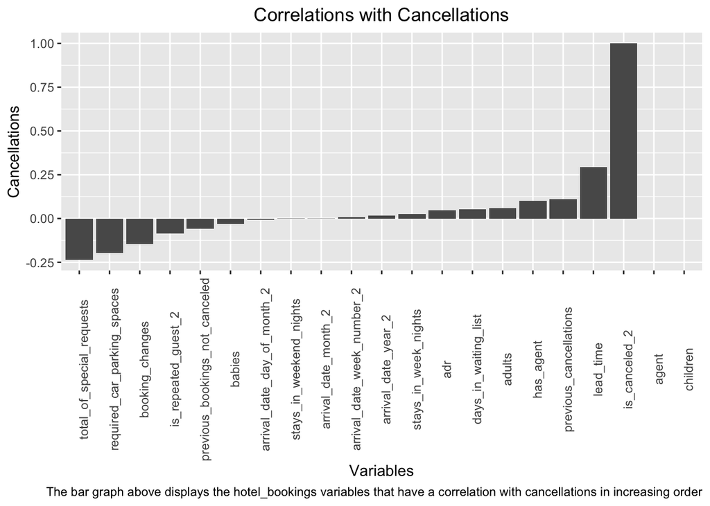

```r
#defactorize (change to numeric)
hotel$arrival_date_year_2 <- as.numeric(hotel$arrival_date_year)
hotel$arrival_date_month_2 <- as.numeric(hotel$arrival_date_month)
hotel$arrival_date_week_number_2 <- as.numeric(hotel$arrival_date_week_number)
hotel$is_repeated_guest_2 <- as.numeric(hotel$is_repeated_guest)
hotel$arrival_date_day_of_month_2 <- as.numeric(hotel$arrival_date_day_of_month)

#calculate correlations to figure out which variables could be important
correlations <- as.data.frame(cor(hotel[sapply(hotel, function(x) is.numeric(x))])[16,])
correlations %>% ggplot(aes(x=reorder(rownames(correlations), correlations[,1]), y=correlations[,1])) +
  geom_bar(stat = 'identity') + ggtitle("Correlations with Cancellations") + labs(x="Variables", y="Cancellations",caption=("The bar graph above displays the hotel_bookings variables that have a correlation with cancellations in increasing order")) + theme(plot.title = element_text(hjust = 0.5), axis.text.x = element_text(angle = 90))
```

*Evidenced by the above graph, lead time, previous cancellations, and if the guest had an agent are the most positively correlated with cancellations. This means that each of these variables increase and decrease together with cancellations. On the other hand, the total number of special requests, requested car parking spaces, and number of booking changes are negatively correlated. It is interesting to note that the length of the stay, days on waiting list, and time of year were not closely correlated with cancellations at all. Next, we will take a deeper dive into the variables identified as having the greatest positive and negative correlations.*

**A: Special Requests**

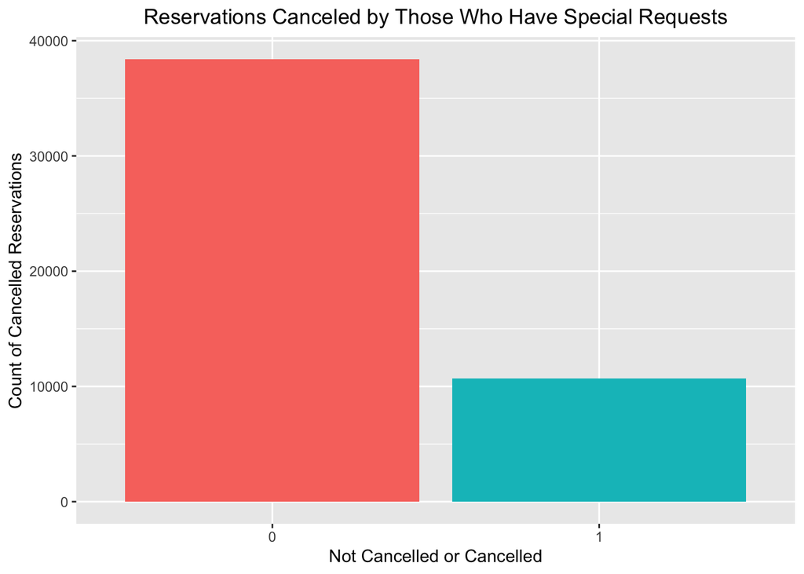

```r
#cancellations by those with special requests
special_requests <- hotel[hotel$total_of_special_requests > 0,]
ggplot(special_requests, aes(is_canceled, fill= is_canceled))+ geom_bar() +  labs(x="Not Cancelled or Cancelled", y= "Count of Cancelled Reservations") + theme(plot.title = element_text(hjust = 0.5)) + ggtitle("Reservations Canceled by Those Who Have Special Requests") + guides(fill = FALSE)
```

*The above graph displays the count of reservations canceled and not canceled by people who have made at least 1 special request.*  
Proportion of those with special requests who have canceled:

```r
#proportions
prop.table(table(special_requests$is_canceled))
```

```
##
##         0         1
## 0.7826052 0.2173948
```

*The above table shows that of the people who have made at least one special request, 21.7% cancel their booking, and 78.3% do not cancel.*  
Proportion of those with NO special requests who have canceled:

```r
#proportions
special_requests_no <- hotel[hotel$total_of_special_requests == 0,]
prop.table(table(special_requests_no$is_canceled))
```

```
##
##         0         1
## 0.5227964 0.4772036
```

*The above table shows that of the people who have not made any special requests, 47.7% cancel their booking, and 52.3% do not cancel.*

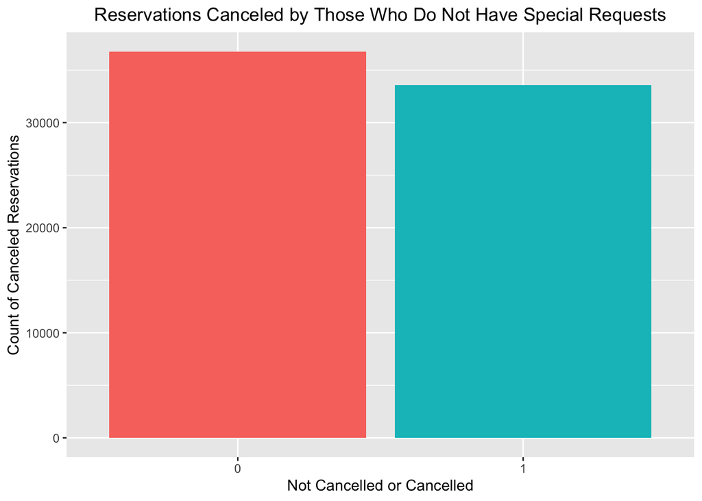

```r
#cancellations by those with no special requests
ggplot(special_requests_no, aes(is_canceled, fill= is_canceled))+ geom_bar() +  labs(x="Not Cancelled or Cancelled", y= "Count of Canceled Reservations") + theme(plot.title = element_text(hjust = 0.5)) + ggtitle("Reservations Canceled by Those Who Do Not Have Special Requests") + guides(fill = FALSE)
```

Summary of Lead Time:

```r
#lead times
summary(hotel$lead_time)
```

```
##    Min. 1st Qu.  Median    Mean 3rd Qu.    Max.
##       0      18      69     104     160     737
```

*Lead time ranges from 0 to 737. A lead time of 0 means the person booked on the same day as arrival, while 737 indicates booking of 737 days prior to arrival. The average individual books 104 days prior.*

Using the quartile information provided above, we then created buckets of lead time to better understand the data.

Lead time bucket breakdown:

Lowest Lead Time: 0 - 17

Low/Middle Lead Time: 18 - 68

High/Middle Lead Time: 69 - 160

Highest Lead Time: 160 - 737

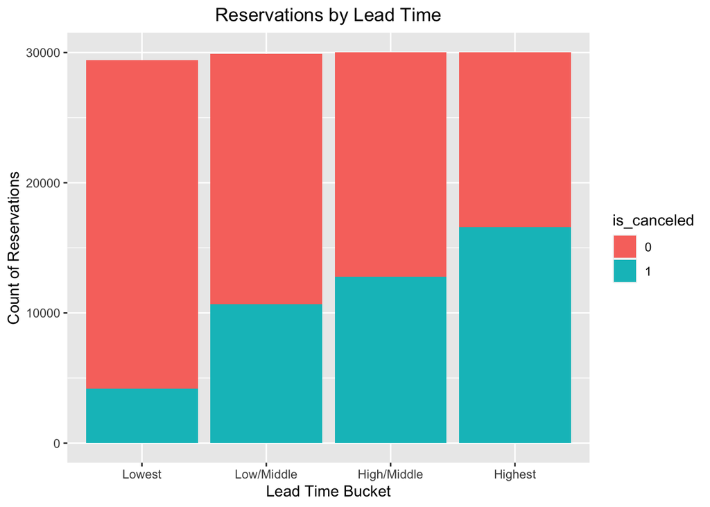

```r
#Cancellations based on lead times
hotel$lead_time_range <- cut(hotel$lead_time,
                             breaks = c(0, 18, 69, 160, 738), right = FALSE,
                             labels = c( "Lowest", "Low/Middle", "High/Middle", "Highest"))


    ggplot(hotel, aes(lead_time_range, fill= is_canceled))+ geom_bar() +  labs(x="Lead Time Bucket", y= "Count of Reservations") + theme(plot.title = element_text(hjust = 0.5)) + ggtitle("Reservations by Lead Time")
```

*The above graph displays the count of reservations canceled and not canceled, grouped by various lead time buckets.*

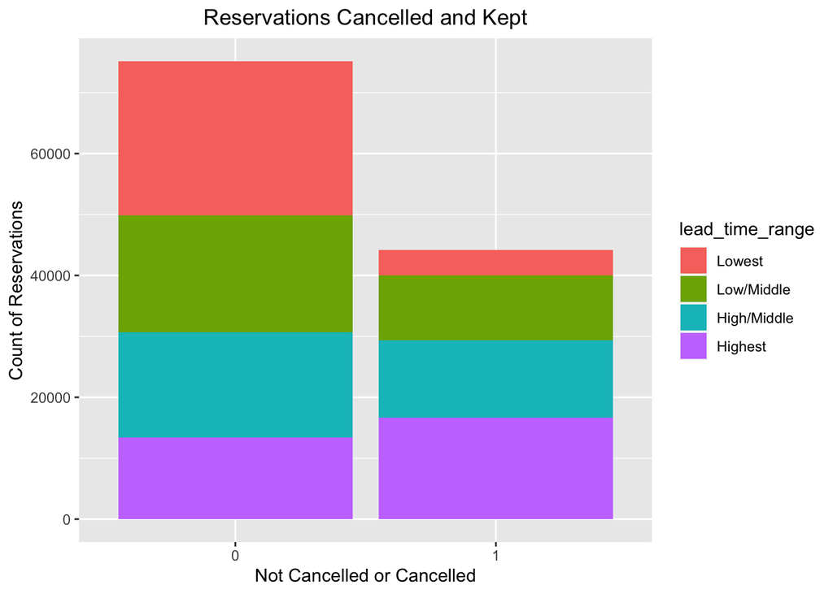

```r
#Reservations cancelled and kept by lead time
ggplot(hotel, aes(x=is_canceled, fill=lead_time_range)) + geom_bar() + ggtitle("Reservations Cancelled and Kept") + theme(plot.title = element_text(hjust = 0.5)) + xlab("Not Cancelled or Cancelled") + ylab("Count of Reservations")
```

*Above are two graphical representations of the relationship between lead time and cancellations. We can see that as the lead time increases, so does the chances of cancellation. Below, we will conduct additional analysis.*  
LT Prop Table 1: Prop table showing percentage of each lead time group that canceled/did not cancel. 1 indicates cancellation.

```r
#proportions per lead time group
prop.table(table(hotel$lead_time_range, hotel$is_canceled),1)
```

```
##
##                       0         1
##   Lowest      0.8583951 0.1416049
##   Low/Middle  0.6433945 0.3566055
##   High/Middle 0.5743171 0.4256829
##   Highest     0.4468014 0.5531986
```

*People with the lowest lead time canceled just 14.2% of the time, low/middle 35.7% of the time, middle/high 42.6% of the time, and highest lead time canceled 55.3% of the time. We see that the greater the lead time, the higher a chance that the person canceled.*

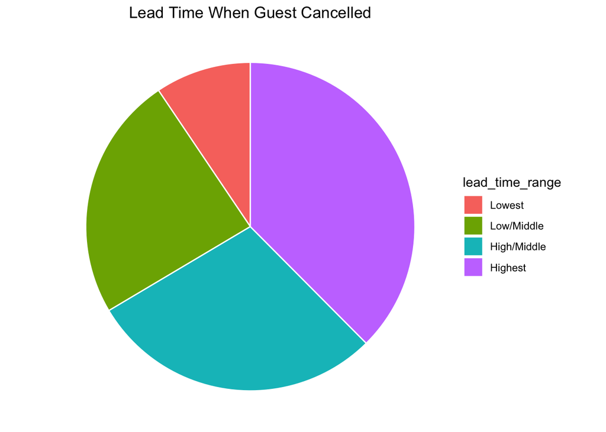

```r
#lead time when guest cancelled
hotel_is_canceled <- hotel[!(hotel$is_canceled == 0),]
hotel_is_canceled %>% group_by(lead_time_range) %>% summarize(n=n()) %>% ggplot(aes("", n, fill = lead_time_range)) + geom_bar(stat = 'identity', width = 1, color = "white") + coord_polar("y", start = 0) + theme_void() + labs(title = "Lead Time When Guest Cancelled") + theme(plot.title = element_text(hjust = 0.5))
```

*The pie chart above shows that when a guest canceled, they were more likely to be from the highest lead time bucket than any other group.*

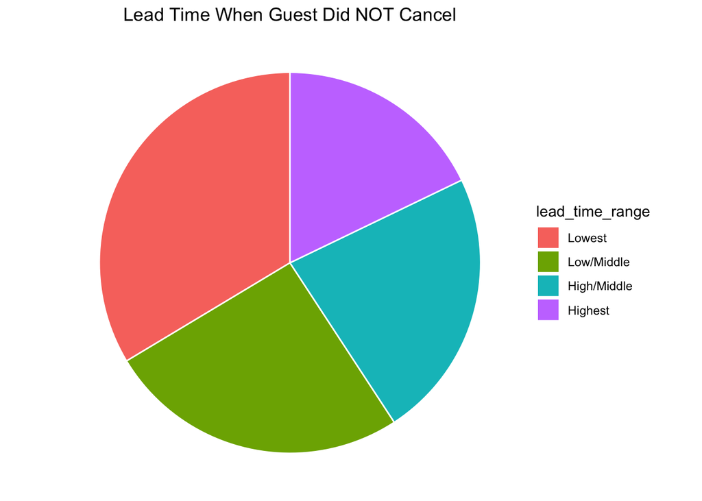

```r
#lead time when not cancelled
hotel_is_not_canceled <- hotel[!(hotel$is_canceled == 1),]
hotel_is_not_canceled %>% group_by(lead_time_range) %>% summarize(n=n()) %>% ggplot(aes("", n, fill = lead_time_range)) + geom_bar(stat = 'identity', width = 1, color = "white") + coord_polar("y", start = 0) + theme_void() + labs(title = "Lead Time When Guest Did NOT Cancel") + theme(plot.title = element_text(hjust = 0.5))
```

*The pie chart above shows that when a guest did not cancel, they were more likely to be from the lowest lead time bucket than any other group.*  
Next, we want to dive a bit deeper to understand the lead time data. We will look at the distribution of lead time and and how it varies by time of year.

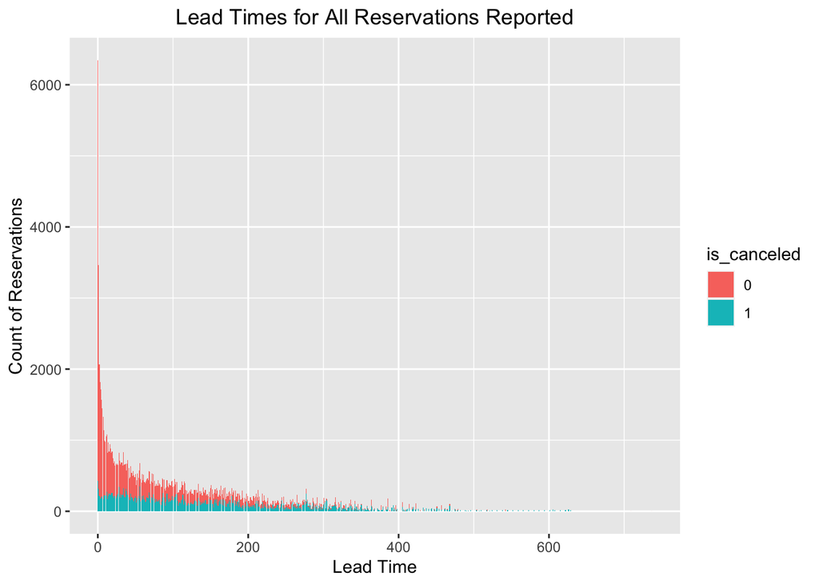

```r
#distribution of lead time
ggplot(hotel, aes(lead_time,  fill = is_canceled)) + geom_bar()  +  labs(x="Lead Time", y= "Count of Reservations") + theme(plot.title = element_text(hjust = 0.5)) + ggtitle("Lead Times for All Reservations Reported")
```

*Clearly, most people book with a lead time less than 100 days, with a few outliers who book 600 days in advanced.*

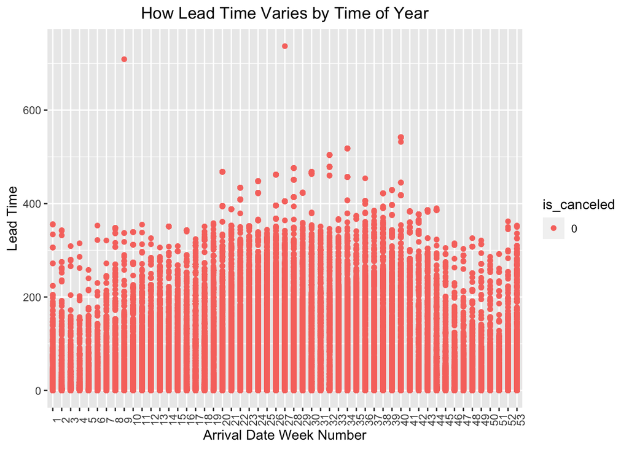

```r
#distribution of lead time by time of year
ggplot(hotel_is_not_canceled, aes(arrival_date_week_number, lead_time,  colour = is_canceled)) + geom_point()  +  labs(x="Arrival Date Week Number", y= "Lead Time") + theme(plot.title = element_text(hjust = 0.5), axis.text.x = element_text(angle = 90)) + ggtitle("How Lead Time Varies by Time of Year")
```

Now, we want to look if having an agent has an affect on the rate of cancellation. 0 means that they do not have an agent.

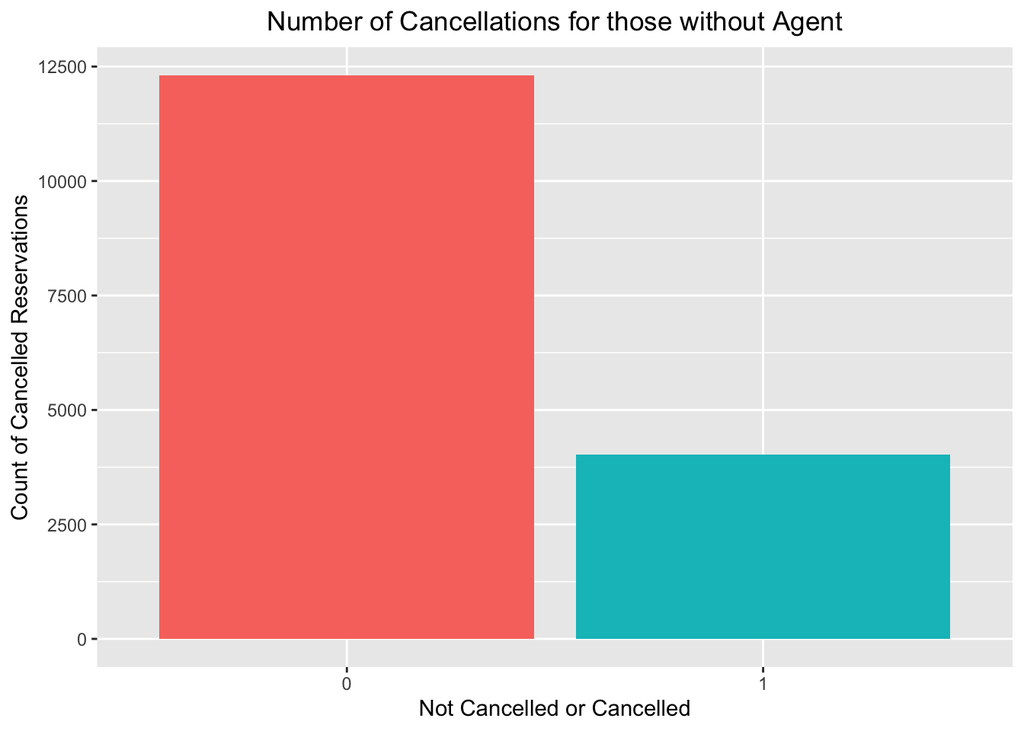

```r
#plot of people number of cancellations without agent
ggplot(data=hotel[hotel$has_agent == 0,], aes(x=is_canceled,fill= is_canceled)) + ggtitle("Number of Cancellations for those without Agent") + xlab("Not Cancelled or Cancelled") + ylab("Count of Cancelled Reservations") + geom_bar() + theme(plot.title = element_text(hjust = 0.5)) + guides(fill = FALSE)
```

Proportion of people who canceled who did not have an agent:

```r
#proportion who cancelled without agents
sum(hotel$has_agent == 0 & hotel$is_canceled == 1)/sum(hotel$has_agent == 0)
```

```
## [1] 0.246634
```

Proportion of people who canceled who had an agent:

```r
#proportion who cancelled with agents
sum(hotel$has_agent != 0 & hotel$is_canceled == 1)/sum(hotel$has_agent != 0)
```

```
## [1] 0.3900437
```

*Of people with no agent, 24.7% of people canceled. Of the people with an agent, 39% of people canceled. Interestingly enough, people with an agent canceled more.*

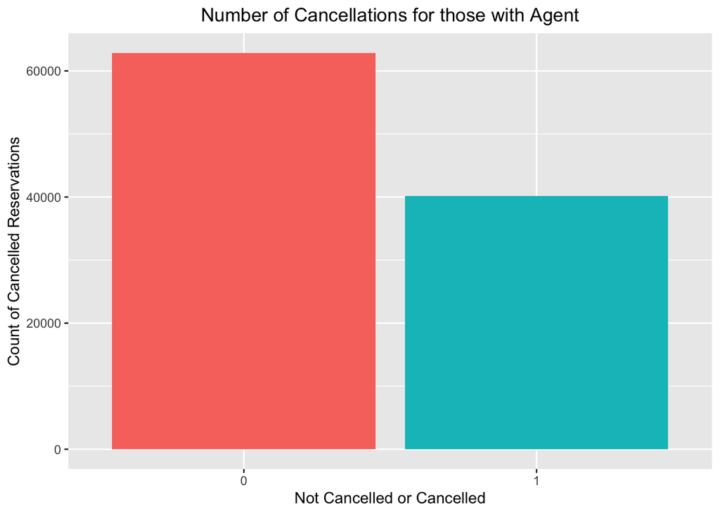

```r
#plot of number of cancellations with agent
ggplot(data=hotel[hotel$has_agent == 1,], aes(x=is_canceled,fill= is_canceled)) + ggtitle("Number of Cancellations for those with Agent") + xlab("Not Cancelled or Cancelled") + ylab ("Count of Cancelled Reservations") + geom_bar() + theme(plot.title = element_text(hjust = 0.5)) + guides(fill = FALSE)
```

**D: Booking Changes**

Now, lets look at the relationship between booking changes and cancellation rate.

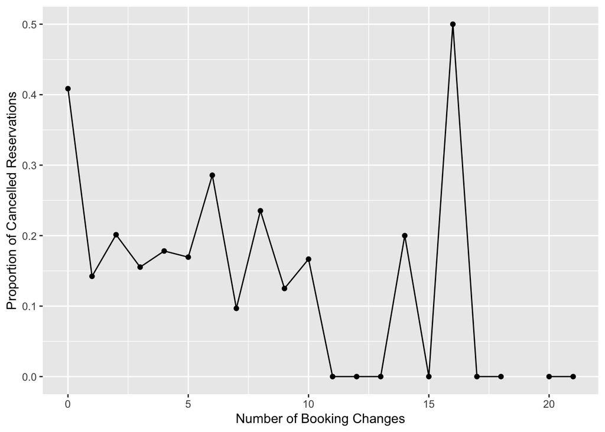

```r
#loop
proportion_canceled = c()
for(i in 0:21){
  proportion_canceled[i+1] = nrow(hotel[hotel$booking_changes== i  & hotel$is_canceled == 1,])/nrow(hotel[hotel$booking_changes== i,])
}

#proportions cancelled based on number of booking changes
ggplot(as.data.frame(proportion_canceled), aes(x= c(0:21), y= proportion_canceled)) + geom_line() + geom_point() + xlab("Number of Booking Changes") + ylab("Proportion of Cancelled Reservations")
```

*The graph above shows that the higher the number of booking changes, the smaller the proportion of the bookings being canceled. There is a noticeable exception when the booking changes is at 16. This is due to the fact that there are only two people who have 16 booking changes, one of which canceled. That explain the large variation in the data at that point. Note that we have to exclude the point at which booking changes is 19 because there is no person in the data who has exactly 19 booking changes.*  
**E: Previous Cancellations**

Proportion of those who have previously canceled that canceled:

```r
#prop of those who previously cancelled that cancelled again
has_canceled <- hotel[hotel$previous_cancellations > 0,]
prop.table(table(has_canceled$is_canceled))
```

```
##
##          0          1
## 0.08359038 0.91640962
```

*The above table shows that of the people who have previously canceled, 91.6% cancel their booking, and 8.4% do not cancel.*

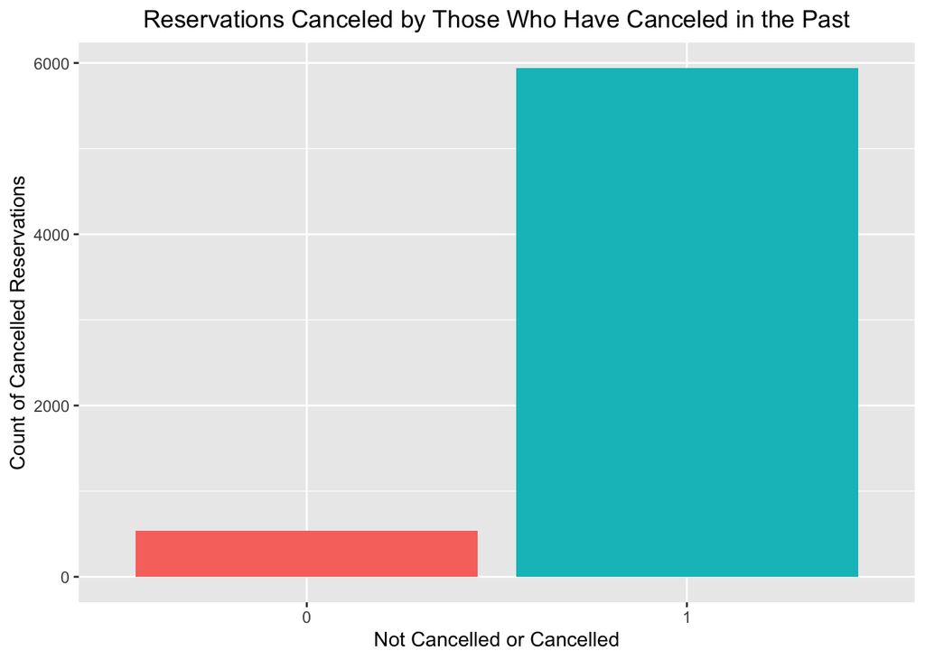

```r
#number of those who previously cancelled that cancelled again
ggplot(has_canceled, aes(is_canceled, fill= is_canceled)) + geom_bar() + labs(x="Not Cancelled or Cancelled", y= "Count of Cancelled Reservations")+ theme(plot.title = element_text(hjust = 0.5)) + ggtitle("Reservations Canceled by Those Who Have Canceled in the Past") + guides(fill = FALSE)
```

*Clearly, people who have canceled in the past cancel a lot more than they maintain their reservations.*  
*Conclusion: Based on the above findings, we see that if someone has canceled their reservation in the past, they are highly likely to cancel once again. This is an example of the motif: “The best indicator of future behavior is past behavior”.*

### Solutions to the Cancellation Problem

**Why Are Cancelations Such a Large Issue?**

The main reason that cancellations are a problem is because if the hotel is at capacity, or if the most profitable rooms have been booked, then you are missing out on lost revenue from the customers that would have booked and not canceled. One solution to this problem would be to force those that have canceled before to put down a deposit when they reserve in order to mitigate any losses that may occur from the lost revenue of other potential customers. Another solution is to reserve rooms mostly for customers that have not canceled in the past. You would apply Newsvendor Problem solving logic to determine the number of rooms that you leave reserved.

A final solution that should be used in conjunction with the others is utilize this data to over- or under-book based on projected cancellations. For example, when a large number of people who have canceled in the past book again, a certain percentage should be overbooked to minimize losses.

**Analysis of Special Requests Indicators**

From our analysis, we view that those who have contacted the hotel for special requests are much less likely to cancel their reservation than a client who has not made any special requests. This difference may be because people who make special requests feel more attached to their experience as they’ve personalized it, or maybe only people who are confident they are going to actually stay take the time to make these requests. The hotel should take note of this whenever someone makes a request. However, correlation is not causation and it is not evident whether people decide they are not canceling before they make special requests or if they do not cancel because they have made those requests.

**Lead Time Analysis**

In our lead time analysis, there was a clear relationship between how far in advance a person booked and whether they canceled their reservation or not. The trend showed that the further in advance that someone booked, the more likely they were to cancel their reservation. This is a difficult problem to have because for hotels, early reservations are beneficial for planning and give the hotels a safeguard against the variance in room demand within any given week. Some possible solutions include, like the previous cancellations problem, to mandate that guests put down a deposit when they reserve a room far in advance, especially in our highest lead time bin, which had a cancellation rate of 55.3%. Another solution would be to limit how far out that customers can book reservations. This would make the hotel’s planning more accurate.

**Presence of Agent Analysis**

The agency variable indicates is whether or not someone had a travel agency book their reservation for them. Surprisingly, those who had an agent were more likely to cancel their reservations than those who did not have agents. Since we discovered that those with agents were more likely to cancel, the hotel should do a better job at establishing relationships with these travel agencies and perhaps finding ways to incentivize them to have their clients follow through with their reservations.

**Analysis of Booking Changes**

We found that in general, the higher number of booking changes, the less likely that the reservation would be canceled. As with the number of special requests, people who put more effort and intention into making the trip work may be more intentional about actually coming. We viewed that the more booking changes a person had, the less likely they were to cancel their reservation. This may be because the person feels psychologically indebted to the hotel not to cancel because they have helped them with their booking changes. To ensure this trend continues, the hotel should train staff to be receptive to booking changes.

**Analysis of Previous Cancellations**

Of the people who have previously canceled, 91.6% cancel their booking. Thus, people who have cancelled in the past are far more likely to cancel again. Thus, we suggest overbooking by a certain percentage on days that people who canceled in the past are currently booked. By understanding this data and pattern, the company can now minimize losses when people who have canceled previously cancel again.